# Chromosomal Knob Repeat Analysis — Figure 1 Panels A–C

inv4m

2026-03-09

# Overview

BLAST+ megablast hits of chromosomal knob repeats (knob180 M32524.1 and TR-1 AY083942.1) plotted along chromosome 4 of four *Zea* genomes. Vertical lines mark inversion breakpoint boundaries from AnchorWave genome alignments.

This generates **Figure 1 Panel B** of the inversion paper in two variants:

- **Plot 2** (PT): TIL18 / PT / B73 — three-genome cowplot with crossing lines
- **Plot 3** (Mi21): TIL18 / Mi21 / B73 — same architecture, Mi21 NIL assembly

BLAST searches were run with `scripts/02_genomics_foundation/run_repeat_annotation_4genomes.sh`.

# Load BLAST results

```r
library(dplyr)
library(ggplot2)
library(scales)
library(cowplot)

blastcols <- c("qseqid", "sseqid", "pident", "length", "mismatch",
               "gapopen", "qstart", "qend", "sstart", "send",
               "evalue", "bitscore")

genomes <- c("TIL18", "PT", "Mi21", "B73")

read_blast <- function(rep_label, prefix) {
  files <- setNames(
    file.path(paths$intermediate, paste0(prefix, "_", genomes, ".blast")),
    genomes)
  lapply(genomes, function(g) {
    blast <- read.table(files[g], sep = "\t", header = FALSE,
      col.names = blastcols,
      colClasses = c(qseqid = "character", sseqid = "character"))
    blast$genome <- g
    blast
  }) %>% bind_rows() %>%
    mutate(bitscaled = rescale(bitscore, to = c(0, 100)), rep = rep_label)
}

to_plot <- bind_rows(
  read_blast("knob180", "knob180"),
  read_blast("TR-1", "TR-1")
) %>% mutate(genome = factor(genome, levels = genomes), rep = factor(rep))
```

```r
to_plot %>%
  group_by(genome, rep) %>%
  summarise(n_hits = n(), .groups = "drop") %>%
  tidyr::pivot_wider(names_from = rep, values_from = n_hits)
```

```
## # A tibble: 4 × 3
##   genome knob180 `TR-1`
##   <fct>    <int>  <int>
## 1 TIL18   158444  38277
## 2 PT         783    207
## 3 Mi21       790   5286
## 4 B73       1303   5268
```

# Breakpoint alignment

All genomes are aligned so that the upstream breakpoint maps to the B73 upstream coordinate (172,882,309). This allows visual comparison of inversion extent across genomes.

```r
bp_all <- data.frame(
  genome = c("TIL18","TIL18","PT","PT","B73","B73","Mi21","Mi21"),
  side   = rep(c("upstream","downstream"), 4),
  xpos   = c(180365316, 193570651, 173486186, 186925483,
             172882309, 188131461, 156752504, 167621035),
  stringsAsFactors = FALSE)

b73_upstream <- 172882309
offsets <- bp_all %>% filter(side == "upstream") %>%
  mutate(offset = b73_upstream - xpos) %>% select(genome, offset)
bp_aligned <- bp_all %>% left_join(offsets, by = "genome") %>%
  mutate(xpos_aligned = xpos + offset)
to_plot <- to_plot %>% left_join(offsets, by = "genome") %>%
  mutate(sstart_aligned = sstart + offset)

# Midlines: mean repeat position between breakpoints per genome
midlines <- lapply(unique(bp_all$genome), function(g) {
  bps <- bp_all$xpos[bp_all$genome == g]
  hits <- to_plot %>% filter(genome == g,
    sstart >= min(bps) + 1e6, sstart <= max(bps) - 1e6)
  if (nrow(hits) == 0) return(NULL)
  data.frame(genome = g,
    xmid_aligned = mean(hits$sstart) + offsets$offset[offsets$genome == g])
}) %>% bind_rows()
```

```r
bp_aligned %>% select(genome, side, xpos, xpos_aligned) %>%
  tidyr::pivot_wider(names_from = side, values_from = c(xpos, xpos_aligned))
```

```
## # A tibble: 4 × 5
##   genome xpos_upstream xpos_downstream xpos_aligned_upstream
##   <chr>          <dbl>           <dbl>                 <dbl>
## 1 TIL18      180365316       193570651             172882309
## 2 PT         173486186       186925483             172882309
## 3 B73        172882309       188131461             172882309
## 4 Mi21       156752504       167621035             172882309
## # ℹ 1 more variable: xpos_aligned_downstream <dbl>
```

# Plot 1: Four-genome faceted overview

Simple faceted plot of all four genomes at native coordinates (no alignment).

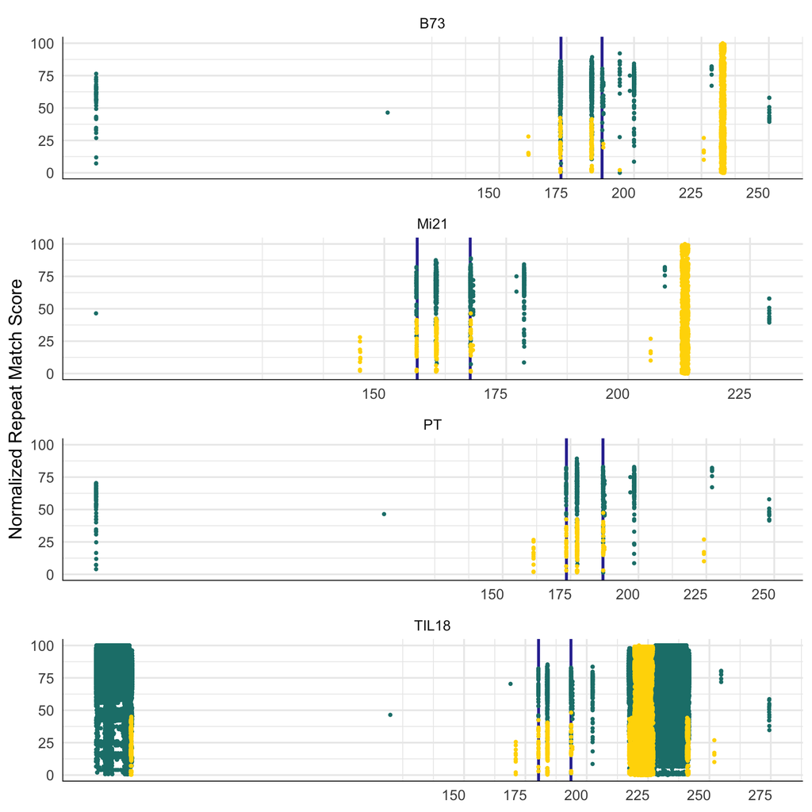

```r
annotations <- bp_all %>%
  mutate(genome = factor(genome, levels = genomes))

p_faceted <- to_plot %>%
  ggplot(aes(x = sstart, y = bitscaled, color = rep)) +
  ylab("Normalized Repeat Match Score") +
  geom_vline(data = annotations, aes(xintercept = xpos),
             color = "#3232a0", linewidth = 1.2) +
  geom_point(size = 0.8) +
  facet_wrap(~ genome, nrow = 4, ncol = 1, scales = "free_x") +
  scale_color_manual(values = c("knob180" = "#1d7f7a", "TR-1" = "gold")) +
  scale_x_continuous(labels = unit_format(unit = "", scale = 1e-6),
                     breaks = seq(150e6, 275e6, by = 25e6)) +
  annotate("segment", x = -Inf, xend = Inf, y = -Inf, yend = -Inf) +
  annotate("segment", x = -Inf, xend = -Inf, y = -Inf, yend = Inf) +
  theme_minimal(base_size = 16) +
  theme(axis.title.x = element_blank(),
        axis.text.x = element_text(hjust = 0.8),
        strip.background = element_blank(),
        legend.position = "none")

p_faceted
```

# Repeat annotation panel config

Color palette, axis config, and SVG canvas dimensions. Layout helper functions are in `fig1_panel_helpers.R`.

```r
# --- Color palette ---
col_inv4m    <- "purple4"
col_knob     <- "#00954A"
col_gold     <- "gold"
col_gray     <- "gray50"
col_ancestry <- "gold"
lw           <- 1.2

cfg <- list(
  xlim    = c(150e6, 235e6),
  xbreaks = seq(150e6, 225e6, by = 25e6))

ENABLE_CONNECTORS <- TRUE

# --- SVG canvas dimensions ---
svg_standalone <- list(W = 648, H = 432, lw = 2.56)   # 9x6 inch standalone
svg_combined   <- list(W = 725.76, H = 576, lw = 2.56) # Panel A viewport in 18x8

# Active svg/xtick_x — set by build_repeat_panel() per variant
svg <- svg_standalone
xtick_x <- c("175" = 160.11, "200" = 306.61, "225" = 453.10, "250" = 599.59)

# --- Load panel helpers (source into current environment so helpers see our variables) ---
source(here("scripts", "inversion_paper", "fig1_panel_helpers.R"), local = TRUE)
```

# Plot 2: TIL18 / PT / B73

```r
variant_pt <- list(
  genomes = c("TIL18", "PT", "B73"),
  svg = svg_standalone,
  xtick_x = c("175" = 160.11, "200" = 306.61, "225" = 453.10, "250" = 599.59),
  vlines = list(
    TIL18 = list(up_x = 147.70, dn_x = 225.08, top_y = 57.75,  bot_y = 140.45),
    PT    = list(up_x = 147.70, dn_x = 226.45, top_y = 170.33, bot_y = 253.03),
    B73   = list(up_x = 147.70, dn_x = 237.06, top_y = 282.91, bot_y = 351.81)),
  mid_x = list(TIL18 = 168.76, PT = 170.64, B73 = 214.67),
  pairs = list(
    list(top = "TIL18", bot = "PT",  inverted = FALSE),
    list(top = "PT",    bot = "B73", inverted = TRUE)),
  genome_labels = list(
    list(name = "TIL18", y = 0.835,  desc_html = "teosinte *mexicana*"),
    list(name = "PT",    y = 0.574, desc = "highland maize"),
    list(name = "B73",   y = 0.314, desc = NULL)),
  ancestry = c("mexicana", "mexicana", "b73"))
```

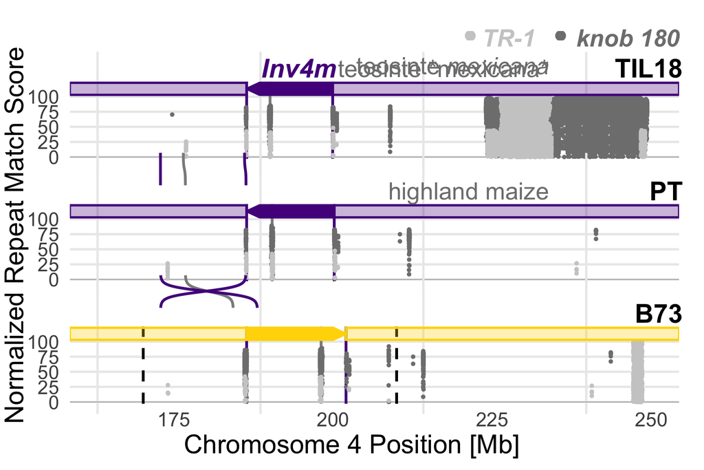

```r
make_pt <- build_repeat_panel(variant_pt)
make_pt(TRUE)
```

```r
ggsave(file.path(paths$figures, "fig1_panel_B_skeleton.svg"),
       plot = make_pt(FALSE), width = 9, height = 6, device = "svg",
       fix_text_size = TRUE)
ggsave(file.path(paths$figures, "fig1_panel_B_skeleton.png"),
       plot = make_pt(TRUE), width = 9, height = 6, dpi = 300, bg = "white")
```

# Plot 3: TIL18 / Mi21 / B73

```r
variant_mi21 <- list(
  genomes = c("TIL18", "Mi21", "B73"),
  svg = svg_combined,
  xtick_x = c("150" = 95.49, "175" = 265.18, "200" = 434.87, "225" = 604.56),
  vlines = list(
    TIL18 = list(up_x = 250.80, dn_x = 340.44, top_y = 103.13, bot_y = 194.99),
    Mi21  = list(up_x = 250.80, dn_x = 324.58, top_y = 253.24, bot_y = 345.09),
    B73   = list(up_x = 250.80, dn_x = 354.31, top_y = 403.35, bot_y = 495.20)),
  mid_x = list(TIL18 = 275.19, Mi21 = 277.22, B73 = 328.37),
  pairs = list(
    list(top = "TIL18", bot = "Mi21", inverted = FALSE),
    list(top = "Mi21",  bot = "B73",  inverted = TRUE)),
  genome_labels = list(
    list(name = "TIL18", y = 0.835,  desc = "teosinte mexicana"),
    list(name = "Mi21 NIL", y = 0.574, desc = "highland maize"),
    list(name = "B73",   y = 0.314, desc = NULL)),
  introgression = list(mi21_left = 155.45, mi21_right = 190.79,
                       b73_left  = 157.01, b73_right  = 195.90),
  ancestry = c("mexicana", "nil", "b73"))
```

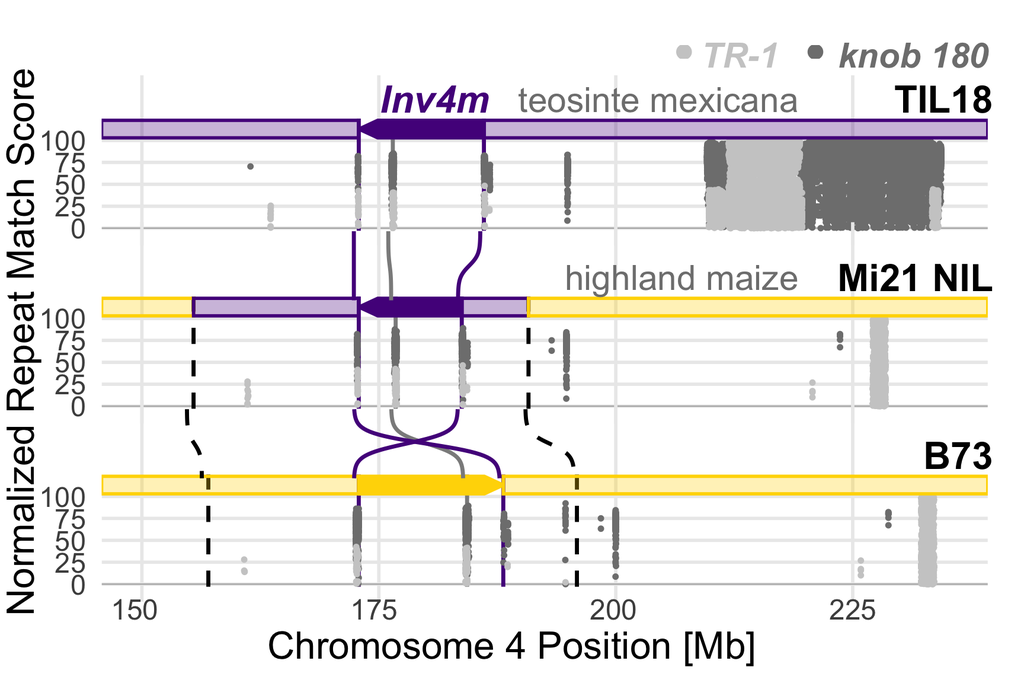

```r
make_mi21 <- build_repeat_panel(variant_mi21)
make_mi21(TRUE)
```

```r
ggsave(file.path(paths$figures, "fig1_panel_B_mi21_skeleton.svg"),
       plot = make_mi21(FALSE), width = 9, height = 6, device = "svg",
       fix_text_size = TRUE)
ggsave(file.path(paths$figures, "fig1_panel_B_mi21_skeleton.png"),
       plot = make_mi21(TRUE), width = 9, height = 6, dpi = 300, bg = "white")
```

# Panel C: Breakpoint self-similarity dotplots

LAST self-vs-self dotplots at upstream and downstream Inv4m breakpoint segments. Dotplots were generated by `scripts/02_genomics_foundation/run_breakpoint_dotplots_4genomes.sh`.

The figure uses three genomes matching the Panel B Mi21 variant: TIL18, Mi21 NIL, B73.

```r
library(png)

panel_c_genomes <- c("TIL18", "Mi21", "B73")

panel_c_coords <- list(
  TIL18 = list(up = "180269950-180365316", down = "193570651-193734606"),
  Mi21  = list(up = "156519809-156752504", down = "167621035-167839092"),
  B73   = list(up = "172561959-172882309", down = "188131461-188220418"))

panel_c_labels <- c(TIL18 = "TIL18", Mi21 = "Mi21 NIL", B73 = "B73")

seg_size_kb <- function(range_str) {
  parts <- as.numeric(strsplit(range_str, "-")[[1]])
  round((parts[2] - parts[1]) / 1e3)
}

# Rotate PNG array 90 degrees counter-clockwise
rotate_ccw <- function(img) {
  aperm(img[, rev(seq_len(ncol(img))), , drop = FALSE], c(2, 1, 3))
}

read_dotplot <- function(genome, direction) {
  fname <- sprintf("%s_brkpt_%s.png", genome, direction)
  fpath <- file.path(paths$intermediate, fname)
  if (!file.exists(fpath)) stop("Missing: ", fpath)
  rotate_ccw(readPNG(fpath))
}

make_dotplot_cell <- function(img, size_kb) {
  ggdraw() +
    draw_image(img, x = 0, y = 0.1, width = 1, height = 0.9) +
    draw_label(paste0(size_kb, " kb"), x = 0.5, y = 0.06, size = 14, color = "gray30")
}
```

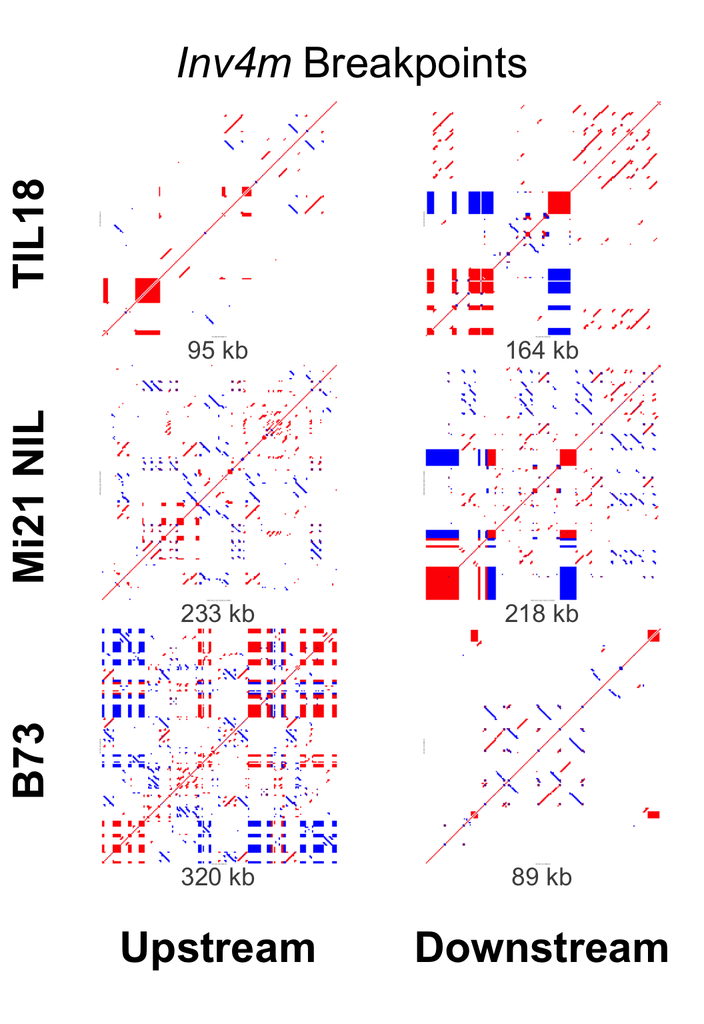

```r
# Mi21 PNGs are named by B73-sense orientation but the inversion flips
# upstream/downstream, so swap which file goes in which column
png_dir <- list(
  TIL18 = c(up = "up", down = "down"),
  Mi21  = c(up = "down", down = "up"),
  B73   = c(up = "up", down = "down"))

cells <- list()
for (g in panel_c_genomes) {
  for (dir in c("up", "down")) {
    img <- read_dotplot(g, png_dir[[g]][dir])
    coord_key <- dir
    size <- seg_size_kb(panel_c_coords[[g]][[coord_key]])
    cells[[paste0(g, "_", dir)]] <- make_dotplot_cell(img, size)
  }
}

# Assemble 3x2 grid with genome labels
rows <- lapply(panel_c_genomes, function(g) {
  label <- ggdraw() + draw_label(panel_c_labels[g], size = 24, fontface = "bold", angle = 90)
  plot_grid(label, cells[[paste0(g, "_up")]], cells[[paste0(g, "_down")]],
            nrow = 1, rel_widths = c(0.08, 0.46, 0.46))
})

col_headers <- plot_grid(
  ggdraw(),
  ggdraw() + draw_label("Upstream", size = 24, fontface = "bold", y = 0.24),
  ggdraw() + draw_label("Downstream", size = 24, fontface = "bold", y = 0.24),
  nrow = 1, rel_widths = c(0.08, 0.46, 0.46))

title_row <- ggdraw() +
  draw_label(expression(italic("Inv4m") ~ "Breakpoints"), x = 0.50, y = 0.5, size = 24, fontface = "bold")

p_panelc_brkpt <- plot_grid(
  ggdraw(),  # top spacer — align with Panel B header
  title_row,
  rows[[1]], rows[[2]], rows[[3]],
  col_headers,
  ggdraw(),  # bottom spacer — align with Panel B x-axis
  ncol = 1, rel_heights = c(0.03, 0.07, 0.26, 0.26, 0.26, 0.07, 0.06))

p_panelc_brkpt
```

```r
ggsave(file.path(paths$figures, "Fig1_panel_C.png"),
       plot = p_panelc_brkpt, width = 5.5, height = 8, dpi = 300, bg = "white")
ggsave(file.path(paths$figures, "Fig1_panel_C.svg"),
       plot = p_panelc_brkpt, width = 5.5, height = 8, device = "svg",
       fix_text_size = TRUE)
```

# Panel A: Inv4m chromosome 4 dotplots (Mi21 vs references)

AnchorWave whole-genome alignment dotplots zoomed to chromosome 4, showing Mi21 NIL (x-axis) vs reference genomes (y-axis). The inversion appears as a reversed diagonal in B73 (standard karyotype) but not in TIL18 or PT (inverted karyotype).

Data from `nilhifimi21/anchorwave/vs_{B73,PT}/dotplot.tab`, filtered to chr4 vs scf00000010_RagTag (Mi21 chr4).

```r
# AnchorWave dotplot format: ref_chr ref_pos query_chr query_pos strand
read_dotplot_tab <- function(file, ref_label) {
  d <- read.table(file, header = FALSE, sep = "\t",
    col.names = c("ref_chr", "ref_pos", "query_chr", "query_pos", "strand"))
  d$ref <- ref_label
  d
}

panel_a_files <- list(
  B73 = file.path(paths$intermediate, "Mi21_vs_B73_chr4.tab"),
  PT  = file.path(paths$intermediate, "Mi21_vs_PT_chr4.tab"))

# TIL18: use real data if available, otherwise duplicate PT as placeholder
# (both carry the inversion so the dotplot pattern is similar)
til18_file <- file.path(paths$intermediate, "Mi21_vs_TIL18_chr4.tab")
if (file.exists(til18_file)) {
  panel_a_files[["TIL18"]] <- til18_file
}

dotplot_data <- do.call(rbind, lapply(names(panel_a_files), function(ref) {
  read_dotplot_tab(panel_a_files[[ref]], ref)
}))

# If TIL18 not available, duplicate PT data as TIL18 placeholder
if (!"TIL18" %in% dotplot_data$ref) {
  til18_placeholder <- dotplot_data[dotplot_data$ref == "PT", ]
  til18_placeholder$ref <- "TIL18"
  dotplot_data <- rbind(til18_placeholder, dotplot_data)
}

# Order top to bottom: TIL18, PT, B73
dotplot_data$ref <- factor(dotplot_data$ref, levels = c("TIL18", "PT", "B73"))

cat("References available:", paste(levels(dotplot_data$ref), collapse = ", "), "\n")
```

```
## References available: TIL18, PT, B73
```

```r
cat("Anchor points per reference:\n")
```

```
## Anchor points per reference:
```

```r
print(table(dotplot_data$ref))
```

```
##
## TIL18    PT   B73
##  6100  3131  2641
```

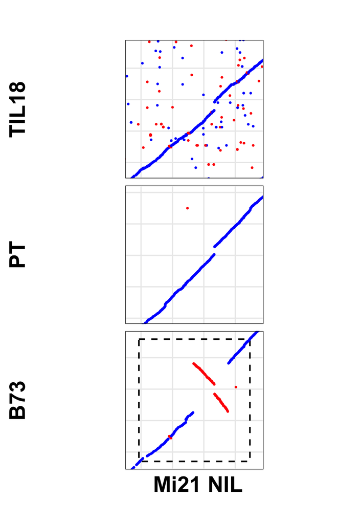

```r
# Color by strand: + = blue (collinear), - = red (inverted)
# Zoom: 25 Mb window per genome, centered on each genome's Inv4m midpoint
zoom_half <- 20

# Introgression boundaries (from AnchorWave offset analysis)
introg_mi21 <- c(139.32, 174.66)  # Mi21 native Mb (x-axis)
introg_b73  <- c(157.01, 195.90)  # B73 Mb  (y-axis)

# Mi21 introgression center (x-axis, shared)
mi21_center <- mean(introg_mi21)  # ~155.5

# Reference centers (y-axis, per genome)
# B73: center on introgression; TIL18/PT: center on inversion
ref_centers <- c(
  TIL18 = (180365316 + 193570651) / 2 / 1e6,  # 187.0
  PT    = (173486186 + 186925483) / 2 / 1e6,   # 180.2
  B73   = mean(introg_b73))                     # 174.5

# Build one dotplot per genome with coord_fixed and proper zoom
make_dotplot_facet <- function(genome, show_xlab = FALSE) {
  d <- dotplot_data[dotplot_data$ref == genome, ]
  yc <- ref_centers[genome]

  p <- ggplot(d, aes(x = query_pos / 1e6, y = ref_pos / 1e6, color = strand)) +
    { if (genome == "B73")
        annotate("rect",
                 xmin = introg_mi21[1], xmax = introg_mi21[2],
                 ymin = introg_b73[1],  ymax = introg_b73[2],
                 fill = NA, color = "black", linewidth = 0.8, linetype = "dashed") } +
    geom_point(size = 0.5) +
    scale_color_manual(values = c("+" = "blue", "-" = "red"), guide = "none") +
    coord_fixed(ratio = 1,
                xlim = c(mi21_center - zoom_half, mi21_center + zoom_half),
                ylim = c(yc - zoom_half, yc + zoom_half)) +
    labs(x = NULL, y = NULL) +
    theme_minimal(base_size = 14) +
    theme(panel.border = element_rect(color = "black", fill = NA, linewidth = 0.5),
          panel.grid.minor = element_blank(),
          axis.text = element_blank(),
          axis.ticks = element_blank(),
          plot.margin = margin(4, 2, 4, 2))
  p
}

# Stack with genome labels on the left — flush left to align with "A" label
panel_a_plots <- lapply(c("TIL18", "PT", "B73"), function(g) {
  label <- ggdraw() + draw_label(g, size = 24, fontface = "bold", angle = 90, x = 0.6)
  plot_grid(label, make_dotplot_facet(g, show_xlab = (g == "B73")),
            nrow = 1, rel_widths = c(0.08, 0.92))
})

p_panela <- plot_grid(
  ggdraw(),  # top spacer — align with Panel B header
  panel_a_plots[[1]], panel_a_plots[[2]], panel_a_plots[[3]],
  ggdraw() + draw_label("Mi21 NIL", size = 24, fontface = "bold", x = 0.55),
  ggdraw(),  # bottom spacer — align with Panel B x-axis
  ncol = 1, rel_heights = c(0.25, 1, 1, 1, 0.15, 0.20))

p_panela
```

```r
ggsave(file.path(paths$figures, "Fig1_panel_A.png"),
       plot = p_panela, width = 5.5, height = 8, dpi = 300, bg = "white")
ggsave(file.path(paths$figures, "Fig1_panel_A.svg"),
       plot = p_panela, width = 5.5, height = 8, device = "svg",
       fix_text_size = TRUE)
```

# Combined layout: Panels A + B + C

Assemble the three panels side by side. Panel A (repeat annotation) is wide, Panel B (AnchorWave dotplots) is narrow, Panel C (breakpoint dotplots) is medium — placing the two dotplot panels adjacent.

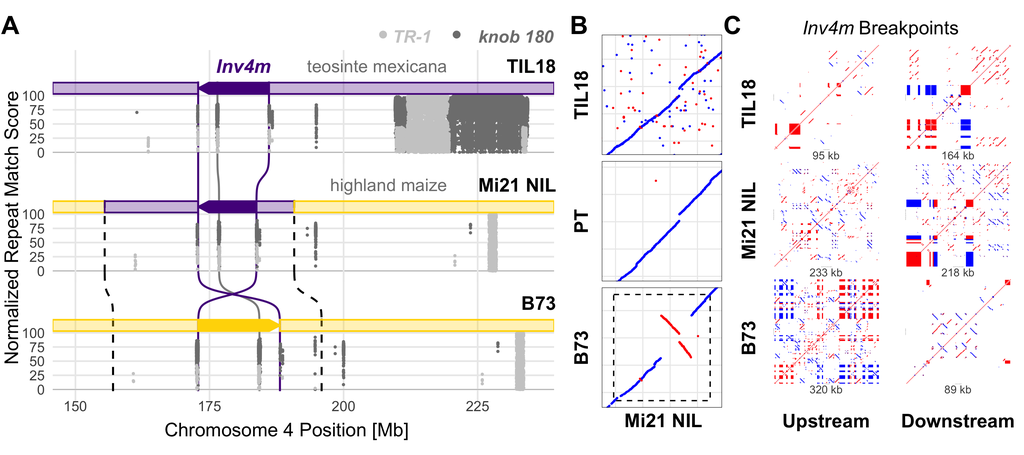

```r
# Build combined figure helper (skeleton vs points for SVG vs PNG)
build_fig1_top <- function(show_points) {
  p_repeat <- make_mi21(show_points)

  fig1_grid <- plot_grid(
    p_repeat,
    p_panela,
    p_panelc_brkpt,
    nrow = 1,
    rel_widths = c(0.56, 0.16, 0.28))

  label_y <- 0.965
  ggdraw(fig1_grid) +
    draw_label("A", x = 0.005, y = label_y, size = 32, fontface = "bold",
               hjust = 0.2, vjust = 1) +
    draw_label("B", x = 0.56,  y = label_y, size = 32, fontface = "bold",
               hjust = 0.2, vjust = 1) +
    draw_label("C", x = 0.71,  y = label_y, size = 32, fontface = "bold",
               hjust = 0.2, vjust = 1)
}

build_fig1_top(TRUE)
```

```r
ggsave(file.path(paths$figures, "Fig1_top_ABC.png"),
       plot = build_fig1_top(TRUE), width = 18, height = 8, dpi = 300, bg = "white")
ggsave(file.path(paths$figures, "Fig1_top_ABC.svg"),
       plot = build_fig1_top(FALSE), width = 18, height = 8, device = "svg",
       fix_text_size = TRUE)
```